# Data Analysis & Visualization: Fountain Pen Ink

# Introduction

This page presents a quantitative analysis of fountain pen ink characteristics using data gathered from over 15,000 customer reviews. Inks with no reviews were excluded from the analysis. N = 548 inks. Some ink products of the same name are represented at multiple volumes (*e.g.* 30mL, 50mL). All items sharing a name are included as each item includes its own review statistics.

# Data Source

The data for this analysis were gathered in late September 2019 with permission from https://www.gouletpens.com/ and results have been shared with them. The inks represented here were found in the ‘bottled inks’ section of the site.

# Characteristics

The data used for this analysis feature several ink characteristics: drying, flow, shading, value, and water resistance. Each characteristic was scored by reviewers on a five-point scale (1 to 5). The table below provides additional information regarding each scale.

| Score | Drying | Flow | Shading | Value | WaterResistance |
| --- | --- | --- | --- | --- | --- |
| 1 | slow | dry | low | low | low |
| 2 |  |  |  |  |  |
| 3 | medium | medium | medium | medium | medium |
| 4 |  |  |  |  |  |
| 5 | fast | wet | high | high | high |

# Review Count

### Review Count Distribution

The distribution for the number of reviews is skewed heavily to the right and is spread over a wide range of values.

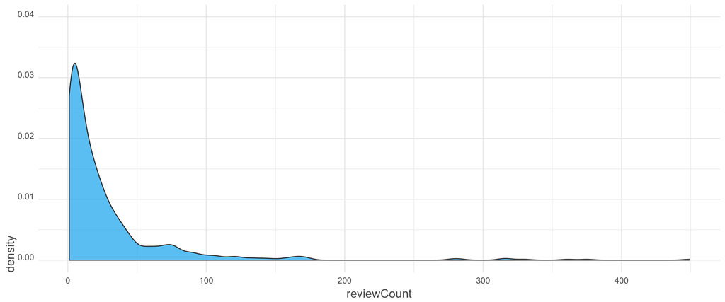

### Review Count by Brand

Inks from the Noodler’s brand have been reviewed far more often than those of any other brand. Diamine and Pilot round out the Top 3 most-reviewed brands.

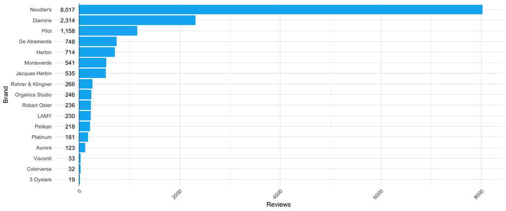

# Rating

### Distribution

The rating distribution is heavily skewed and it seems reviewers are quite generous with their given scores.

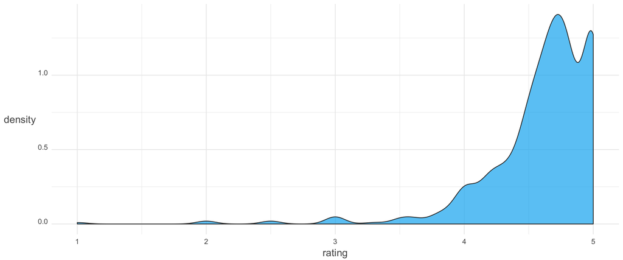

### Average Rating by Brand

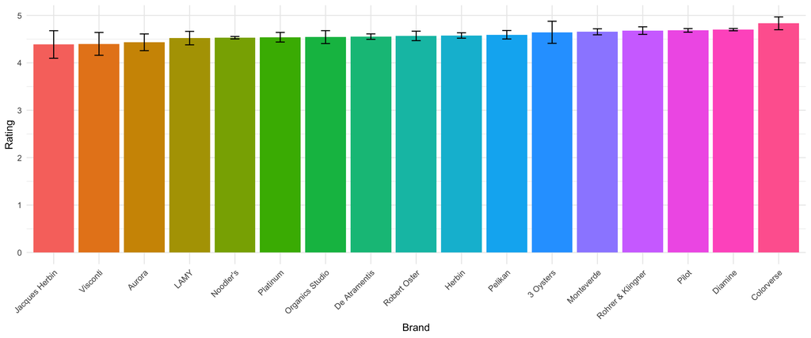

# Drying

## Distribution

Ink drying (slow to fast) appears to be approximately normally distributed with perhaps some preference given for whole number scores.

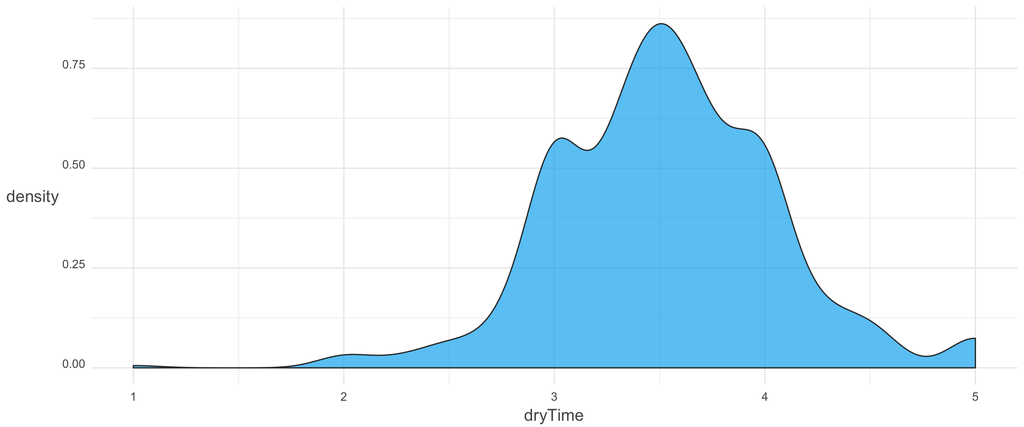

## Drying by Brand

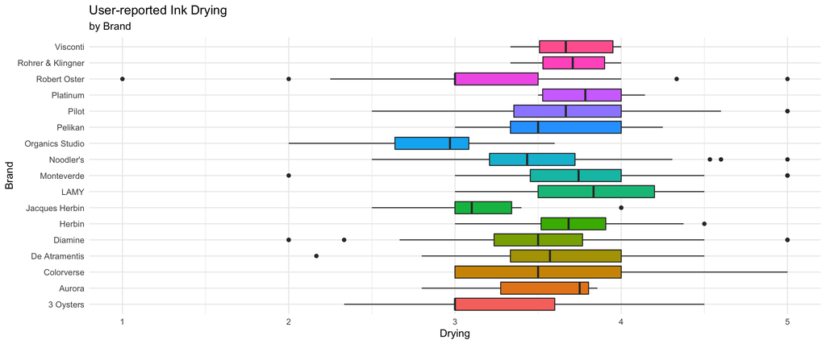

### Top-rated Inks (Slow Dry Time)

These inks were selected for a drying score less than or equal to three (slow), a review count over 30, and a value rating of over 4.5.

| Brand | Ink | Volume | Reviews | Rating | Drying | Flow | Shading | Value | WaterResistance | Link |
| --- | --- | --- | --- | --- | --- | --- | --- | --- | --- | --- |
| Noodler’s | Midnight Blue | 3oz | 30 | 4.6 | 2.50 | 3.67 | 3.17 | 5.00 | 2.17 | [Midnight Blue](https://www.gouletpens.com/products/noodlers-midnight-blue-3oz-bottled-ink?variant=11884736053291) |
| Noodler’s | Ottoman Azure | 3oz | 70 | 4.6 | 2.80 | 3.85 | 3.53 | 4.79 | 2.31 | [Ottoman Azure](https://www.gouletpens.com/products/noodlers-ottoman-azure-3oz-bottled-ink?variant=11884737429547) |
| Noodler’s | Habanero | 3oz | 91 | 4.7 | 2.82 | 3.97 | 4.26 | 4.68 | 2.30 | [Habanero](https://www.gouletpens.com/products/noodlers-habanero-3oz-bottled-ink?variant=11884736774187) |
| Noodler’s | Burgundy | 3oz | 34 | 4.8 | 2.83 | 3.83 | 3.00 | 4.67 | 2.40 | [Burgundy](https://www.gouletpens.com/products/noodlers-burgundy-3oz-bottled-ink?variant=11884736348203) |
| Noodler’s | Turquoise Eel | 3oz | 36 | 4.7 | 2.83 | 4.08 | 3.58 | 4.92 | 1.73 | [Turquoise Eel](https://www.gouletpens.com/products/noodlers-turquoise-eel-3oz-bottled-ink?variant=11884743819307) |
| Noodler’s | Blue Eel | 3oz | 89 | 4.6 | 2.86 | 4.07 | 3.29 | 4.79 | 2.42 | [Blue Eel](https://www.gouletpens.com/products/noodlers-blue-eel-3oz-bottled-ink?variant=11884743655467) |
| Noodler’s | Polar Black | 3oz | 35 | 4.6 | 2.86 | 4.00 | 1.83 | 4.86 | 4.00 | [Polar Black](https://www.gouletpens.com/products/noodlers-polar-black-3oz-bottled-ink?variant=11884742934571) |
| Diamine | Chocolate Brown | 30ml | 34 | 4.8 | 2.92 | 3.75 | 3.08 | 4.75 | 2.33 | [Chocolate Brown](https://www.gouletpens.com/products/diamine-chocolate-brown-30ml-bottled-ink?variant=11884621987883) |
| Diamine | Sargasso Sea | 30ml | 43 | 4.4 | 2.93 | 3.64 | 2.85 | 4.54 | 2.78 | [Sargasso Sea](https://www.gouletpens.com/products/diamine-sargasso-sea-30ml-bottled-ink?variant=11884624248875) |
| Noodler’s | Golden Brown | 3oz | 60 | 4.7 | 3.00 | 4.00 | 4.20 | 4.63 | 2.72 | [Golden Brown](https://www.gouletpens.com/products/noodlers-golden-brown-3oz-bottled-ink?variant=11884736315435) |
| Noodler’s | Tiananmen | 3oz | 42 | 4.7 | 3.00 | 3.38 | 3.25 | 5.00 | 2.43 | [Tiananmen](https://www.gouletpens.com/products/noodlers-tiananmen-3oz-bottled-ink?variant=11884737462315) |
| Noodler’s | Apache Sunset | 3oz | 330 | 4.6 | 3.00 | 3.71 | 4.42 | 4.64 | 2.57 | [Apache Sunset](https://www.gouletpens.com/products/noodlers-apache-sunset-3oz-bottled-ink?variant=11884736839723) |
| Noodler’s | Bluerase Waterase Ink | 4.5oz | 36 | 4.5 | 3.00 | 4.27 | 2.18 | 4.55 | 1.27 | [Bluerase Waterase Ink](https://www.gouletpens.com/products/noodlers-bluerase-waterase-ink-4-5oz-bottled-ink?variant=11884745130027) |

### Top-rated Inks (Fast Dry Time)

These inks were selected for a drying score greater than or equal to four (fast), a review count over 30, and a value rating of over 4.5.

| Brand | Ink | Volume | Reviews | Rating | Drying | Flow | Shading | Value | WaterResistance | Link |
| --- | --- | --- | --- | --- | --- | --- | --- | --- | --- | --- |
| Pilot | Iroshizuku Syo-ro | 50ml | 39 | 4.6 | 5.00 | 5.00 | 4.00 | 5.00 | 5.00 | [Iroshizuku Syo-ro](https://www.gouletpens.com/products/pilot-iroshizuku-syo-ro-50ml-bottled-ink?variant=11884756828203) |
| Pilot | Iroshizuku Yu-yake | 50ml | 42 | 4.7 | 4.60 | 4.20 | 3.60 | 5.00 | 3.00 | [Iroshizuku Yu-yake](https://www.gouletpens.com/products/pilot-iroshizuku-yu-yake-50ml-bottled-ink?variant=11884757090347) |
| Noodler’s | Bernanke Black | 3oz | 65 | 4.3 | 4.53 | 3.93 | 3.07 | 4.53 | 3.43 | [Bernanke Black](https://www.gouletpens.com/products/noodlers-bernanke-black-3oz-bottled-ink?variant=11884740083755) |
| Noodler’s | Lexington Gray | 4.5oz | 119 | 4.8 | 4.31 | 4.08 | 4.08 | 4.62 | 4.60 | [Lexington Gray](https://www.gouletpens.com/products/noodlers-lexington-gray-4-5oz-bottled-ink?variant=11884744343595) |
| LAMY | Black | 50ml | 33 | 4.6 | 4.23 | 3.38 | 2.92 | 4.69 | 2.55 | [Black](https://www.gouletpens.com/products/lamy-black-50ml-bottled-ink?variant=11884712525867) |
| Noodler’s | Year of the Golden Pig | 4.5oz | 36 | 4.0 | 4.20 | 3.80 | 1.40 | 5.00 | 4.50 | [Year of the Golden Pig](https://www.gouletpens.com/products/noodlers-year-golden-pig-4-5oz-bottled-ink?variant=11884744376363) |
| Pilot | Iroshizuku Murasaki-shikibu | 50ml | 37 | 4.8 | 4.12 | 3.75 | 2.75 | 4.50 | 3.62 | [Iroshizuku Murasaki-shikibu](https://www.gouletpens.com/products/pilot-iroshizuku-murasaki-shikibu-50ml-bottled-ink?variant=11884757581867) |
| De Atramentis | Archive Ink | 35ml | 37 | 4.9 | 4.11 | 4.00 | 2.77 | 4.71 | 4.63 | [Archive Ink](https://www.gouletpens.com/products/de-atramentis-archive-35ml-bottled-ink?variant=11884635389995) |
| Diamine | Syrah | 80ml | 86 | 4.7 | 4.07 | 3.47 | 3.29 | 4.87 | 2.50 | [Syrah](https://www.gouletpens.com/products/diamine-syrah-80ml-bottled-ink?variant=11884629262379) |
| De Atramentis | Document Ink Black | 35ml | 69 | 4.9 | 4.05 | 3.93 | 3.19 | 4.57 | 4.76 | [Document Ink Black](https://www.gouletpens.com/products/de-atramentis-document-black-35ml-bottled-ink?variant=11884635324459) |
| Noodler’s | Bad Black Moccasin | 3oz | 78 | 4.7 | 4.05 | 3.72 | 2.28 | 4.79 | 4.47 | [Bad Black Moccasin](https://www.gouletpens.com/products/noodlers-bad-black-moccasin-3oz-bottled-ink?variant=11884739887147) |
| Pilot | Iroshizuku Take-sumi | 50ml | 67 | 4.9 | 4.00 | 4.29 | 3.18 | 4.71 | 3.06 | [Iroshizuku Take-sumi](https://www.gouletpens.com/products/pilot-iroshizuku-take-sumi-50ml-bottled-ink?variant=11884757745707) |
| Noodler’s | Polar Blue | 3oz | 40 | 4.4 | 4.00 | 3.92 | 1.77 | 4.69 | 4.67 | [Polar Blue](https://www.gouletpens.com/products/noodlers-polar-blue-3oz-bottled-ink?variant=11884743950379) |
| Pilot | Namiki Black | 60ml | 30 | 4.4 | 4.00 | 4.00 | 3.00 | 5.00 | 3.00 | [Namiki Black](https://www.gouletpens.com/products/pilot-namiki-black-60ml-bottled-ink?variant=11884755615787) |
| Noodler’s | Bad Green Gator | 3oz | 75 | 4.2 | 4.00 | 3.88 | 3.25 | 5.00 | 4.62 | [Bad Green Gator](https://www.gouletpens.com/products/noodlers-bad-green-gator-3oz-bottled-ink?variant=11884740018219) |
| Noodler’s | Rome Burning | 3oz | 54 | 4.1 | 4.00 | 3.85 | 2.33 | 4.50 | 4.23 | [Rome Burning](https://www.gouletpens.com/products/noodlers-rome-burning-3oz-bottled-ink?variant=11884739854379) |

# Flow

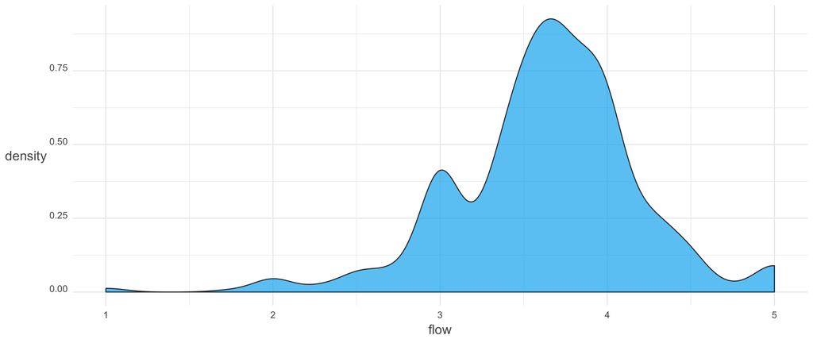

## Flow by Brand

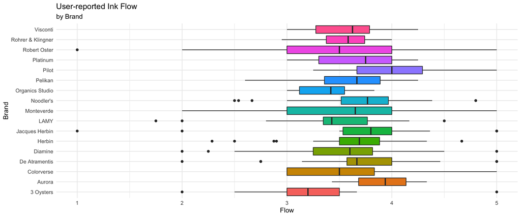

### Top-rated Inks (Dry Flow)

These inks were selected for a flow score less than or equal to three (dry), a review count over 30, and a value rating of over 4.5.

| Brand | Ink | Volume | Reviews | Rating | Drying | Flow | Shading | Value | WaterResistance | Link |
| --- | --- | --- | --- | --- | --- | --- | --- | --- | --- | --- |
| Herbin | Cacao du Brésil | 30ml | 37 | 4.8 | 3.7 | 2.90 | 3.00 | 4.70 | 2.33 | [Cacao du Brésil](https://www.gouletpens.com/products/herbin-cacao-du-bresil-30ml-bottled-ink?variant=11884653838379) |
| Rohrer & Klingner | Salix | 50ml | 53 | 4.7 | 3.9 | 2.95 | 3.45 | 4.89 | 4.68 | [Salix](https://www.gouletpens.com/products/rohrer-klingner-salix-50ml-bottled-ink?variant=11884769902635) |

### Top-rated Inks (Wet Flow)

These inks were selected for a flow score greater than or equal to four (wet), a review count over 30, and a value rating of over 4.5.

| Brand | Ink | Volume | Reviews | Rating | Drying | Flow | Shading | Value | WaterResistance | Link |
| --- | --- | --- | --- | --- | --- | --- | --- | --- | --- | --- |
| Pilot | Iroshizuku Syo-ro | 50ml | 39 | 4.6 | 5.00 | 5.00 | 4.00 | 5.00 | 5.00 | [Iroshizuku Syo-ro](https://www.gouletpens.com/products/pilot-iroshizuku-syo-ro-50ml-bottled-ink?variant=11884756828203) |
| Pilot | Iroshizuku Kiri-same | 50ml | 31 | 4.7 | 3.33 | 4.33 | 3.67 | 5.00 | 3.67 | [Iroshizuku Kiri-same](https://www.gouletpens.com/products/pilot-iroshizuku-kiri-same-50ml-bottled-ink?variant=11884756992043) |
| Pilot | Iroshizuku Yama-budo | 50ml | 79 | 4.9 | 3.40 | 4.30 | 3.20 | 4.90 | 2.20 | [Iroshizuku Yama-budo](https://www.gouletpens.com/products/pilot-iroshizuku-yama-budo-50ml-bottled-ink?variant=11884756959275) |
| Pilot | Iroshizuku Take-sumi | 50ml | 67 | 4.9 | 4.00 | 4.29 | 3.18 | 4.71 | 3.06 | [Iroshizuku Take-sumi](https://www.gouletpens.com/products/pilot-iroshizuku-take-sumi-50ml-bottled-ink?variant=11884757745707) |
| Pilot | Iroshizuku Shin-kai | 50ml | 61 | 4.8 | 3.29 | 4.29 | 2.29 | 4.86 | 2.29 | [Iroshizuku Shin-kai](https://www.gouletpens.com/products/pilot-iroshizuku-shin-kai-50ml-bottled-ink?variant=11884757778475) |
| Noodler’s | Bluerase Waterase Ink | 4.5oz | 36 | 4.5 | 3.00 | 4.27 | 2.18 | 4.55 | 1.27 | [Bluerase Waterase Ink](https://www.gouletpens.com/products/noodlers-bluerase-waterase-ink-4-5oz-bottled-ink?variant=11884745130027) |
| Pilot | Iroshizuku Yama-guri | 50ml | 45 | 4.8 | 3.50 | 4.25 | 2.75 | 4.75 | 3.00 | [Iroshizuku Yama-guri](https://www.gouletpens.com/products/pilot-iroshizuku-yama-guri-50ml-bottled-ink?variant=11884757516331) |
| De Atramentis | Alexander Hamilton | 35ml | 35 | 4.9 | 3.41 | 4.22 | 3.26 | 4.84 | 2.75 | [Alexander Hamilton](https://www.gouletpens.com/products/de-atramentis-alexander-hamilton-35ml-bottled-ink?variant=11884638896171) |
| Noodler’s | Bad Belted Kingfisher | 3oz | 141 | 4.6 | 3.61 | 4.22 | 2.12 | 4.67 | 4.11 | [Bad Belted Kingfisher](https://www.gouletpens.com/products/noodlers-bad-belted-kingfisher-3oz-bottled-ink?variant=11884739919915) |
| Pilot | Iroshizuku Yu-yake | 50ml | 42 | 4.7 | 4.60 | 4.20 | 3.60 | 5.00 | 3.00 | [Iroshizuku Yu-yake](https://www.gouletpens.com/products/pilot-iroshizuku-yu-yake-50ml-bottled-ink?variant=11884757090347) |
| Noodler’s | Cactus Fruit Eel | 3oz | 75 | 4.8 | 3.38 | 4.08 | 3.64 | 4.96 | 2.25 | [Cactus Fruit Eel](https://www.gouletpens.com/products/noodlers-cactus-fruit-eel-3oz-bottled-ink?variant=11884743852075) |
| Noodler’s | Lexington Gray | 4.5oz | 119 | 4.8 | 4.31 | 4.08 | 4.08 | 4.62 | 4.60 | [Lexington Gray](https://www.gouletpens.com/products/noodlers-lexington-gray-4-5oz-bottled-ink?variant=11884744343595) |
| Noodler’s | Nikita | 4.5oz | 98 | 4.7 | 3.33 | 4.08 | 2.58 | 4.83 | 2.64 | [Nikita](https://www.gouletpens.com/products/noodlers-nikita-4-5oz-bottled-ink?variant=11884744146987) |
| Noodler’s | Turquoise Eel | 3oz | 36 | 4.7 | 2.83 | 4.08 | 3.58 | 4.92 | 1.73 | [Turquoise Eel](https://www.gouletpens.com/products/noodlers-turquoise-eel-3oz-bottled-ink?variant=11884743819307) |
| Noodler’s | Blue Eel | 3oz | 89 | 4.6 | 2.86 | 4.07 | 3.29 | 4.79 | 2.42 | [Blue Eel](https://www.gouletpens.com/products/noodlers-blue-eel-3oz-bottled-ink?variant=11884743655467) |
| De Atramentis | Archive Ink | 35ml | 37 | 4.9 | 4.11 | 4.00 | 2.77 | 4.71 | 4.63 | [Archive Ink](https://www.gouletpens.com/products/de-atramentis-archive-35ml-bottled-ink?variant=11884635389995) |
| Pilot | Iroshizuku Asa-gao | 50ml | 75 | 4.8 | 3.79 | 4.00 | 2.71 | 4.50 | 2.71 | [Iroshizuku Asa-gao](https://www.gouletpens.com/products/pilot-iroshizuku-asa-gao-50ml-bottled-ink?variant=11884755714091) |
| Noodler’s | Golden Brown | 3oz | 60 | 4.7 | 3.00 | 4.00 | 4.20 | 4.63 | 2.72 | [Golden Brown](https://www.gouletpens.com/products/noodlers-golden-brown-3oz-bottled-ink?variant=11884736315435) |
| Noodler’s | Green Marine | 3oz | 43 | 4.7 | 3.33 | 4.00 | 3.40 | 4.73 | 2.86 | [Green Marine](https://www.gouletpens.com/products/noodlers-green-marine-3oz-bottled-ink?variant=11884737658923) |
| Herbin | Perle Noire | 30ml | 60 | 4.6 | 3.71 | 4.00 | 1.87 | 4.65 | 2.83 | [Perle Noire](https://www.gouletpens.com/products/herbin-perle-noire-30ml-bottled-ink?variant=11884652134443) |
| Noodler’s | Polar Black | 3oz | 35 | 4.6 | 2.86 | 4.00 | 1.83 | 4.86 | 4.00 | [Polar Black](https://www.gouletpens.com/products/noodlers-polar-black-3oz-bottled-ink?variant=11884742934571) |
| Noodler’s | Dragon’s Napalm | 4.5oz | 75 | 4.5 | 3.40 | 4.00 | 2.70 | 4.80 | 2.50 | [Dragon’s Napalm](https://www.gouletpens.com/products/noodlers-dragons-napalm-4-5oz-bottled-ink?variant=11884744835115) |
| Pilot | Iroshizuku Fuyu-gaki | 50ml | 45 | 4.5 | 3.50 | 4.00 | 2.00 | 4.50 | 2.50 | [Iroshizuku Fuyu-gaki](https://www.gouletpens.com/products/pilot-iroshizuku-fuyu-gaki-50ml-bottled-ink?variant=11884755484715) |
| Pilot | Namiki Black | 60ml | 30 | 4.4 | 4.00 | 4.00 | 3.00 | 5.00 | 3.00 | [Namiki Black](https://www.gouletpens.com/products/pilot-namiki-black-60ml-bottled-ink?variant=11884755615787) |

# Shading

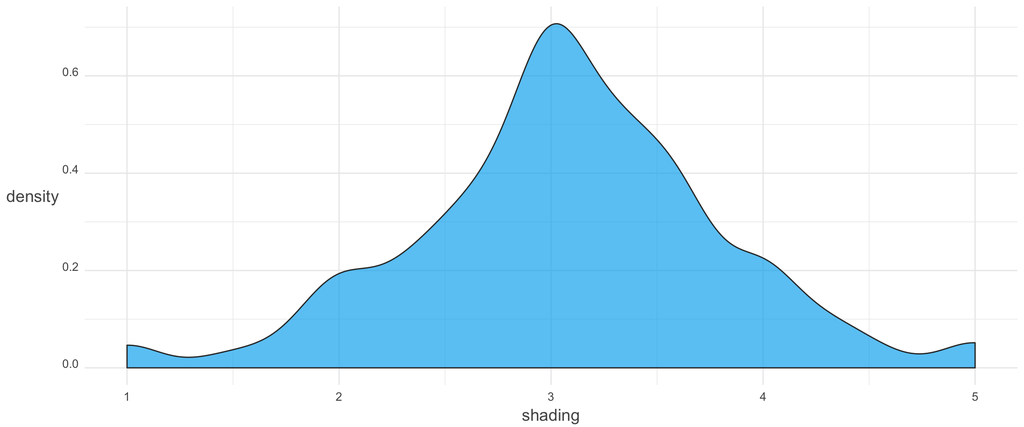

## Shading by Brand

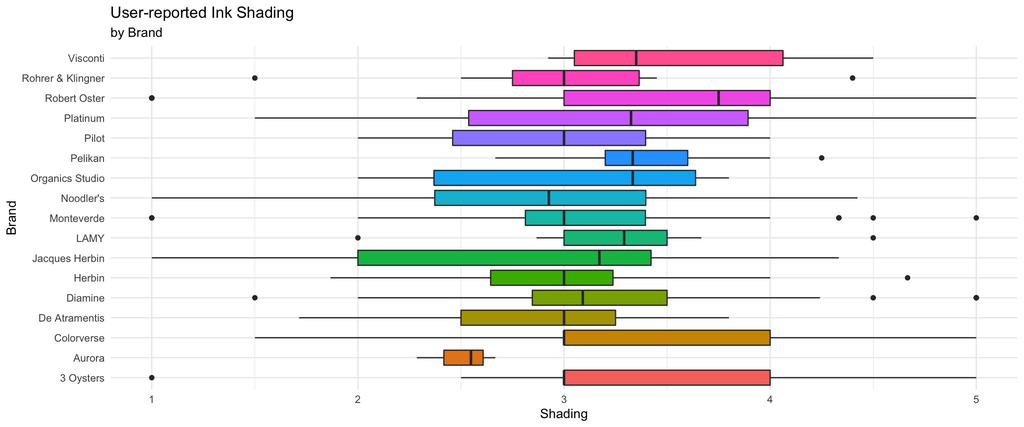

### Top-rated Inks (Low Shading)

These inks were selected for a shading score less than or equal to three (low), a review count over 30, and a value rating of over 4.5.

| Brand | Ink | Volume | Reviews | Rating | Drying | Flow | Shading | Value | WaterResistance | Link |
| --- | --- | --- | --- | --- | --- | --- | --- | --- | --- | --- |
| Noodler’s | Year of the Golden Pig | 4.5oz | 36 | 4.0 | 4.20 | 3.80 | 1.40 | 5.00 | 4.50 | [Year of the Golden Pig](https://www.gouletpens.com/products/noodlers-year-golden-pig-4-5oz-bottled-ink?variant=11884744376363) |
| Noodler’s | Blue Ghost | 3oz | 79 | 4.8 | 3.31 | 3.50 | 1.56 | 4.81 | 4.08 | [Blue Ghost](https://www.gouletpens.com/products/noodlers-blue-ghost-3oz-bottled-ink?variant=11884742770731) |
| Noodler’s | X-Feather | 4.5oz | 133 | 4.7 | 3.56 | 3.46 | 1.70 | 4.68 | 4.13 | [X-Feather](https://www.gouletpens.com/products/noodlers-x-feather-4-5oz-bottled-ink?variant=11884744966187) |
| Noodler’s | Polar Blue | 3oz | 40 | 4.4 | 4.00 | 3.92 | 1.77 | 4.69 | 4.67 | [Polar Blue](https://www.gouletpens.com/products/noodlers-polar-blue-3oz-bottled-ink?variant=11884743950379) |
| Noodler’s | Polar Black | 3oz | 35 | 4.6 | 2.86 | 4.00 | 1.83 | 4.86 | 4.00 | [Polar Black](https://www.gouletpens.com/products/noodlers-polar-black-3oz-bottled-ink?variant=11884742934571) |
| Noodler’s | X-Feather | 3oz | 160 | 4.6 | 3.05 | 3.38 | 1.83 | 4.65 | 3.80 | [X-Feather](https://www.gouletpens.com/products/noodlers-x-feather-3oz-bottled-ink?variant=11884737986603) |
| Herbin | Perle Noire | 30ml | 60 | 4.6 | 3.71 | 4.00 | 1.87 | 4.65 | 2.83 | [Perle Noire](https://www.gouletpens.com/products/herbin-perle-noire-30ml-bottled-ink?variant=11884652134443) |
| Noodler’s | Blue Ghost | 4.5oz | 121 | 4.8 | 3.78 | 3.52 | 1.92 | 4.81 | 3.45 | [Blue Ghost](https://www.gouletpens.com/products/noodlers-blue-ghost-4-5oz-bottled-ink?variant=11884744540203) |
| Pilot | Iroshizuku Fuyu-gaki | 50ml | 45 | 4.5 | 3.50 | 4.00 | 2.00 | 4.50 | 2.50 | [Iroshizuku Fuyu-gaki](https://www.gouletpens.com/products/pilot-iroshizuku-fuyu-gaki-50ml-bottled-ink?variant=11884755484715) |
| Noodler’s | Heart of Darkness | 4.5oz | 315 | 4.7 | 3.96 | 3.90 | 2.04 | 4.72 | 4.10 | [Heart of Darkness](https://www.gouletpens.com/products/noodlers-heart-darkness-4-5oz-bottled-ink?variant=11884744572971) |
| Noodler’s | Bad Belted Kingfisher | 3oz | 141 | 4.6 | 3.61 | 4.22 | 2.12 | 4.67 | 4.11 | [Bad Belted Kingfisher](https://www.gouletpens.com/products/noodlers-bad-belted-kingfisher-3oz-bottled-ink?variant=11884739919915) |
| Noodler’s | Bluerase Waterase Ink | 4.5oz | 36 | 4.5 | 3.00 | 4.27 | 2.18 | 4.55 | 1.27 | [Bluerase Waterase Ink](https://www.gouletpens.com/products/noodlers-bluerase-waterase-ink-4-5oz-bottled-ink?variant=11884745130027) |
| Noodler’s | Blackerase Waterase Ink | 4.5oz | 40 | 4.8 | 3.30 | 3.90 | 2.20 | 4.60 | 2.00 | [Blackerase Waterase Ink](https://www.gouletpens.com/products/noodlers-blackerase-waterase-ink-4-5oz-bottled-ink?variant=11884745064491) |
| Noodler’s | Bad Black Moccasin | 3oz | 78 | 4.7 | 4.05 | 3.72 | 2.28 | 4.79 | 4.47 | [Bad Black Moccasin](https://www.gouletpens.com/products/noodlers-bad-black-moccasin-3oz-bottled-ink?variant=11884739887147) |
| Pilot | Iroshizuku Shin-kai | 50ml | 61 | 4.8 | 3.29 | 4.29 | 2.29 | 4.86 | 2.29 | [Iroshizuku Shin-kai](https://www.gouletpens.com/products/pilot-iroshizuku-shin-kai-50ml-bottled-ink?variant=11884757778475) |
| Noodler’s | Baystate Blue | 3oz | 317 | 4.5 | 3.57 | 3.77 | 2.31 | 4.63 | 4.09 | [Baystate Blue](https://www.gouletpens.com/products/noodlers-baystate-blue-3oz-bottled-ink?variant=11884737626155) |
| Noodler’s | El Lawrence | 3oz | 65 | 4.7 | 3.39 | 3.76 | 2.33 | 4.67 | 4.20 | [El Lawrence](https://www.gouletpens.com/products/noodlers-el-lawrence-3oz-bottled-ink?variant=11884743524395) |
| Noodler’s | Rome Burning | 3oz | 54 | 4.1 | 4.00 | 3.85 | 2.33 | 4.50 | 4.23 | [Rome Burning](https://www.gouletpens.com/products/noodlers-rome-burning-3oz-bottled-ink?variant=11884739854379) |
| Platinum | Carbon Black | 60ml | 99 | 4.8 | 3.61 | 3.46 | 2.45 | 4.57 | 4.80 | [Carbon Black](https://www.gouletpens.com/products/platinum-carbon-black-60ml-bottled-ink?variant=11884753027115) |
| Noodler’s | Baystate Blue | 4.5oz | 283 | 4.7 | 3.77 | 3.77 | 2.45 | 4.77 | 4.11 | [Baystate Blue](https://www.gouletpens.com/products/noodlers-baystate-blue-4-5oz-bottled-ink?variant=11884744769579) |
| Noodler’s | Blue-Black | 3oz | 73 | 4.7 | 3.35 | 3.76 | 2.47 | 4.76 | 3.44 | [Blue-Black](https://www.gouletpens.com/products/noodlers-blue-black-3oz-bottled-ink?variant=11884736413739) |
| Monteverde | Horizon Blue | 90ml | 46 | 4.8 | 3.90 | 3.90 | 2.52 | 4.54 | 2.13 | [Horizon Blue](https://www.gouletpens.com/products/monteverde-horizon-blue-90ml-bottled-ink?variant=11884721176619) |
| Noodler’s | Dark Matter | 3oz | 59 | 4.6 | 3.67 | 3.56 | 2.53 | 4.50 | 3.13 | [Dark Matter](https://www.gouletpens.com/products/noodlers-dark-matter-3oz-bottled-ink?variant=11884738445355) |
| Noodler’s | Black | 3oz | 361 | 4.7 | 3.44 | 3.60 | 2.58 | 4.70 | 4.23 | [Black](https://www.gouletpens.com/products/noodlers-black-3oz-bottled-ink?variant=11884735791147) |
| Noodler’s | Nikita | 4.5oz | 98 | 4.7 | 3.33 | 4.08 | 2.58 | 4.83 | 2.64 | [Nikita](https://www.gouletpens.com/products/noodlers-nikita-4-5oz-bottled-ink?variant=11884744146987) |
| Herbin | Perle Noire | 100ml | 33 | 4.7 | 3.91 | 3.82 | 2.64 | 4.91 | 3.45 | [Perle Noire](https://www.gouletpens.com/products/herbin-perle-noire-100ml-bottled-ink?variant=11884654690347) |
| Diamine | Red Dragon | 80ml | 120 | 4.8 | 3.66 | 3.97 | 2.68 | 4.73 | 2.63 | [Red Dragon](https://www.gouletpens.com/products/diamine-red-dragon-80ml-bottled-ink?variant=11884628049963) |
| Diamine | Wild Strawberry | 30ml | 42 | 4.8 | 3.31 | 3.62 | 2.68 | 4.81 | 2.27 | [Wild Strawberry](https://www.gouletpens.com/products/diamine-wild-strawberry-30ml-bottled-ink?variant=11884622839851) |
| Noodler’s | Dragon’s Napalm | 4.5oz | 75 | 4.5 | 3.40 | 4.00 | 2.70 | 4.80 | 2.50 | [Dragon’s Napalm](https://www.gouletpens.com/products/noodlers-dragons-napalm-4-5oz-bottled-ink?variant=11884744835115) |
| Pilot | Iroshizuku Asa-gao | 50ml | 75 | 4.8 | 3.79 | 4.00 | 2.71 | 4.50 | 2.71 | [Iroshizuku Asa-gao](https://www.gouletpens.com/products/pilot-iroshizuku-asa-gao-50ml-bottled-ink?variant=11884755714091) |
| Diamine | Bilberry | 30ml | 40 | 4.7 | 3.53 | 3.94 | 2.71 | 4.65 | 2.71 | [Bilberry](https://www.gouletpens.com/products/diamine-bilberry-30ml-bottled-ink?variant=11884622938155) |
| Noodler’s | Black Eel | 3oz | 132 | 4.7 | 3.33 | 3.90 | 2.74 | 4.71 | 4.21 | [Black Eel](https://www.gouletpens.com/products/noodlers-black-eel-3oz-bottled-ink?variant=11884743917611) |
| Pilot | Iroshizuku Murasaki-shikibu | 50ml | 37 | 4.8 | 4.12 | 3.75 | 2.75 | 4.50 | 3.62 | [Iroshizuku Murasaki-shikibu](https://www.gouletpens.com/products/pilot-iroshizuku-murasaki-shikibu-50ml-bottled-ink?variant=11884757581867) |
| Pilot | Iroshizuku Yama-guri | 50ml | 45 | 4.8 | 3.50 | 4.25 | 2.75 | 4.75 | 3.00 | [Iroshizuku Yama-guri](https://www.gouletpens.com/products/pilot-iroshizuku-yama-guri-50ml-bottled-ink?variant=11884757516331) |
| De Atramentis | Archive Ink | 35ml | 37 | 4.9 | 4.11 | 4.00 | 2.77 | 4.71 | 4.63 | [Archive Ink](https://www.gouletpens.com/products/de-atramentis-archive-35ml-bottled-ink?variant=11884635389995) |
| Diamine | Red Dragon | 30ml | 46 | 4.8 | 3.77 | 3.55 | 2.85 | 4.61 | 2.65 | [Red Dragon](https://www.gouletpens.com/products/diamine-red-dragon-30ml-bottled-ink?variant=11884622544939) |
| Diamine | Sargasso Sea | 30ml | 43 | 4.4 | 2.93 | 3.64 | 2.85 | 4.54 | 2.78 | [Sargasso Sea](https://www.gouletpens.com/products/diamine-sargasso-sea-30ml-bottled-ink?variant=11884624248875) |
| LAMY | Black | 50ml | 33 | 4.6 | 4.23 | 3.38 | 2.92 | 4.69 | 2.55 | [Black](https://www.gouletpens.com/products/lamy-black-50ml-bottled-ink?variant=11884712525867) |
| Noodler’s | Liberty’s Elysium | 3oz | 449 | 4.6 | 3.71 | 3.54 | 2.93 | 4.53 | 3.57 | [Liberty’s Elysium](https://www.gouletpens.com/products/noodlers-libertys-elysium-3oz-bottled-ink?variant=11884745261099) |
| Noodler’s | Dragon’s Napalm | 3oz | 84 | 4.5 | 3.28 | 3.94 | 2.94 | 4.94 | 2.72 | [Dragon’s Napalm](https://www.gouletpens.com/products/noodlers-dragons-napalm-3oz-bottled-ink?variant=11884738019371) |
| Diamine | Eclipse | 30ml | 42 | 4.7 | 3.86 | 3.57 | 2.95 | 4.82 | 2.60 | [Eclipse](https://www.gouletpens.com/products/diamine-eclipse-30ml-bottled-ink?variant=11884622708779) |
| Herbin | Cacao du Brésil | 30ml | 37 | 4.8 | 3.70 | 2.90 | 3.00 | 4.70 | 2.33 | [Cacao du Brésil](https://www.gouletpens.com/products/herbin-cacao-du-bresil-30ml-bottled-ink?variant=11884653838379) |
| Noodler’s | Burgundy | 3oz | 34 | 4.8 | 2.83 | 3.83 | 3.00 | 4.67 | 2.40 | [Burgundy](https://www.gouletpens.com/products/noodlers-burgundy-3oz-bottled-ink?variant=11884736348203) |
| Noodler’s | Black Swan in English Roses | 3oz | 105 | 4.6 | 3.27 | 3.50 | 3.00 | 4.64 | 3.08 | [Black Swan in English Roses](https://www.gouletpens.com/products/noodlers-black-swan-english-roses-3oz-bottled-ink?variant=11884737560619) |
| Pilot | Namiki Black | 60ml | 30 | 4.4 | 4.00 | 4.00 | 3.00 | 5.00 | 3.00 | [Namiki Black](https://www.gouletpens.com/products/pilot-namiki-black-60ml-bottled-ink?variant=11884755615787) |

### Top-rated Inks (High Shading)

These inks were selected for a shading score greater than or equal to four (high), a review count over 30, and a value rating of over 4.5.

| Brand | Ink | Volume | Reviews | Rating | Drying | Flow | Shading | Value | WaterResistance | Link |
| --- | --- | --- | --- | --- | --- | --- | --- | --- | --- | --- |
| Noodler’s | Apache Sunset | 3oz | 330 | 4.6 | 3.00 | 3.71 | 4.42 | 4.64 | 2.57 | [Apache Sunset](https://www.gouletpens.com/products/noodlers-apache-sunset-3oz-bottled-ink?variant=11884736839723) |
| Rohrer & Klingner | Alt-Goldgrun | 50ml | 90 | 4.8 | 3.62 | 3.75 | 4.40 | 4.86 | 2.41 | [Alt-Goldgrun](https://www.gouletpens.com/products/rohrer-klingner-alt-goldgrun-50ml-bottled-ink?variant=11884769181739) |
| Noodler’s | Habanero | 3oz | 91 | 4.7 | 2.82 | 3.97 | 4.26 | 4.68 | 2.30 | [Habanero](https://www.gouletpens.com/products/noodlers-habanero-3oz-bottled-ink?variant=11884736774187) |
| Noodler’s | Golden Brown | 3oz | 60 | 4.7 | 3.00 | 4.00 | 4.20 | 4.63 | 2.72 | [Golden Brown](https://www.gouletpens.com/products/noodlers-golden-brown-3oz-bottled-ink?variant=11884736315435) |
| Noodler’s | Lexington Gray | 4.5oz | 119 | 4.8 | 4.31 | 4.08 | 4.08 | 4.62 | 4.60 | [Lexington Gray](https://www.gouletpens.com/products/noodlers-lexington-gray-4-5oz-bottled-ink?variant=11884744343595) |
| Robert Oster | Fire & Ice | 50ml | 65 | 4.7 | 3.28 | 3.85 | 4.02 | 4.64 | 2.44 | [Fire & Ice](https://www.gouletpens.com/products/robert-oster-fire-ice-50ml-bottled-ink?variant=11884769574955) |
| Herbin | Lie de The | 30ml | 48 | 4.8 | 3.92 | 3.77 | 4.00 | 4.54 | 2.83 | [Lie de The](https://www.gouletpens.com/products/herbin-lie-de-the-30ml-bottled-ink?variant=11884653707307) |
| Noodler’s | Black Swan in Australian Roses | 3oz | 278 | 4.8 | 3.18 | 3.69 | 4.00 | 4.80 | 3.25 | [Black Swan in Australian Roses](https://www.gouletpens.com/products/noodlers-black-swan-australian-roses-3oz-bottled-ink?variant=11884740116523) |
| Noodler’s | Kiowa Pecan | 3oz | 57 | 4.7 | 3.27 | 3.69 | 4.00 | 4.69 | 2.94 | [Kiowa Pecan](https://www.gouletpens.com/products/noodlers-kiowa-pecan-3oz-bottled-ink?variant=11884736249899) |
| Pilot | Iroshizuku Syo-ro | 50ml | 39 | 4.6 | 5.00 | 5.00 | 4.00 | 5.00 | 5.00 | [Iroshizuku Syo-ro](https://www.gouletpens.com/products/pilot-iroshizuku-syo-ro-50ml-bottled-ink?variant=11884756828203) |
| Noodler’s | Red Black | 3oz | 107 | 4.5 | 3.32 | 3.87 | 4.00 | 4.84 | 3.54 | [Red Black](https://www.gouletpens.com/products/noodlers-red-black-3oz-bottled-ink?variant=11884736184363) |

# Value

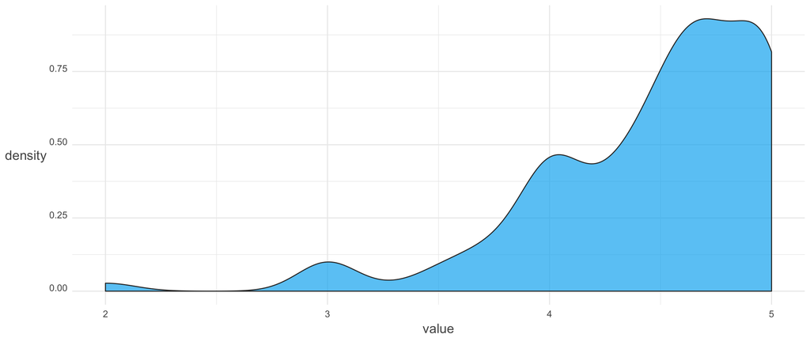

## Value by Brand

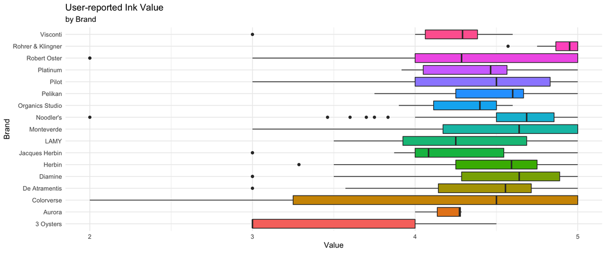

### Top-rated Inks (Low Value)

These inks were selected for a value score less than four (low) and a review count over 30.

| Brand | Ink | Volume | Reviews | Rating | Drying | Flow | Shading | Value | WaterResistance | Link |
| --- | --- | --- | --- | --- | --- | --- | --- | --- | --- | --- |
| Noodler’s | La Reine Mauve | 1oz | 38 | 4.4 | 4.30 | 3.10 | 2.80 | 3.60 | 4.60 | [La Reine Mauve](https://www.gouletpens.com/products/noodlers-la-reine-mauve-1oz-bottled-ink?variant=11884742508587) |
| Pilot | Iroshizuku Fuyu-syogun | 50ml | 44 | 4.5 | 4.00 | 3.67 | 3.00 | 3.67 | 1.67 | [Iroshizuku Fuyu-syogun](https://www.gouletpens.com/products/pilot-iroshizuku-fuyu-syogun-50ml-bottled-ink?variant=11884757319723) |
| Noodler’s | Luxury Blue | 1oz | 32 | 4.1 | 3.50 | 3.30 | 3.10 | 3.70 | 4.67 | [Luxury Blue](https://www.gouletpens.com/products/noodlers-luxury-blue-1oz-bottled-ink?variant=11884742410283) |
| Noodler’s | Empire Red | 3oz | 35 | 4.4 | 3.82 | 3.45 | 2.64 | 3.83 | 4.27 | [Empire Red](https://www.gouletpens.com/products/noodlers-empire-red-3oz-bottled-ink?variant=11884744212523) |
| Jacques Herbin | 1670 Bleu Ocean | 50ml | 64 | 4.4 | 3.30 | 3.80 | 3.14 | 3.87 | 2.48 | [1670 Bleu Ocean](https://www.gouletpens.com/products/jacques-herbin-1670-bleu-ocean-50ml-bottled-ink?variant=11884654460971) |
| LAMY | Bronze | 50ml | 36 | 4.1 | 3.67 | 3.40 | 2.87 | 3.90 | 2.50 | [Bronze](https://www.gouletpens.com/products/lamy-bronze-50ml-bottled-ink?variant=15383375282219) |

### Top-rated Inks (Very High Value)

These inks were selected for a value score greater than or equal to 4.9 (very high) and a review count over 30.

| Brand | Ink | Volume | Reviews | Rating | Drying | Flow | Shading | Value | WaterResistance | Link |
| --- | --- | --- | --- | --- | --- | --- | --- | --- | --- | --- |
| Noodler’s | Gruene Cactus | 3oz | 33 | 4.7 | 3.50 | 3.33 | 3.83 | 5.00 | 2.60 | [Gruene Cactus](https://www.gouletpens.com/products/noodlers-gruene-cactus-3oz-bottled-ink?variant=11884737331243) |
| Noodler’s | Tiananmen | 3oz | 42 | 4.7 | 3.00 | 3.38 | 3.25 | 5.00 | 2.43 | [Tiananmen](https://www.gouletpens.com/products/noodlers-tiananmen-3oz-bottled-ink?variant=11884737462315) |
| Pilot | Iroshizuku Kiri-same | 50ml | 31 | 4.7 | 3.33 | 4.33 | 3.67 | 5.00 | 3.67 | [Iroshizuku Kiri-same](https://www.gouletpens.com/products/pilot-iroshizuku-kiri-same-50ml-bottled-ink?variant=11884756992043) |
| Pilot | Iroshizuku Yu-yake | 50ml | 42 | 4.7 | 4.60 | 4.20 | 3.60 | 5.00 | 3.00 | [Iroshizuku Yu-yake](https://www.gouletpens.com/products/pilot-iroshizuku-yu-yake-50ml-bottled-ink?variant=11884757090347) |
| Noodler’s | Army Green | 3oz | 47 | 4.6 | 3.14 | 3.43 | 3.57 | 5.00 | 2.57 | [Army Green](https://www.gouletpens.com/products/noodlers-army-green-3oz-bottled-ink?variant=11884735725611) |
| Noodler’s | Midnight Blue | 3oz | 30 | 4.6 | 2.50 | 3.67 | 3.17 | 5.00 | 2.17 | [Midnight Blue](https://www.gouletpens.com/products/noodlers-midnight-blue-3oz-bottled-ink?variant=11884736053291) |
| Pilot | Iroshizuku Syo-ro | 50ml | 39 | 4.6 | 5.00 | 5.00 | 4.00 | 5.00 | 5.00 | [Iroshizuku Syo-ro](https://www.gouletpens.com/products/pilot-iroshizuku-syo-ro-50ml-bottled-ink?variant=11884756828203) |
| Pilot | Namiki Black | 60ml | 30 | 4.4 | 4.00 | 4.00 | 3.00 | 5.00 | 3.00 | [Namiki Black](https://www.gouletpens.com/products/pilot-namiki-black-60ml-bottled-ink?variant=11884755615787) |
| Noodler’s | Bad Green Gator | 3oz | 75 | 4.2 | 4.00 | 3.88 | 3.25 | 5.00 | 4.62 | [Bad Green Gator](https://www.gouletpens.com/products/noodlers-bad-green-gator-3oz-bottled-ink?variant=11884740018219) |
| Noodler’s | Year of the Golden Pig | 4.5oz | 36 | 4.0 | 4.20 | 3.80 | 1.40 | 5.00 | 4.50 | [Year of the Golden Pig](https://www.gouletpens.com/products/noodlers-year-golden-pig-4-5oz-bottled-ink?variant=11884744376363) |
| Noodler’s | Cactus Fruit Eel | 3oz | 75 | 4.8 | 3.38 | 4.08 | 3.64 | 4.96 | 2.25 | [Cactus Fruit Eel](https://www.gouletpens.com/products/noodlers-cactus-fruit-eel-3oz-bottled-ink?variant=11884743852075) |
| Noodler’s | Dragon’s Napalm | 3oz | 84 | 4.5 | 3.28 | 3.94 | 2.94 | 4.94 | 2.72 | [Dragon’s Napalm](https://www.gouletpens.com/products/noodlers-dragons-napalm-3oz-bottled-ink?variant=11884738019371) |
| Diamine | Apple Glory | 30ml | 31 | 4.7 | 3.58 | 3.83 | 3.08 | 4.92 | 2.33 | [Apple Glory](https://www.gouletpens.com/products/diamine-apple-glory-30ml-bottled-ink?variant=11884623626283) |
| Noodler’s | Squeteague | 3oz | 43 | 4.7 | 3.50 | 3.67 | 3.58 | 4.92 | 3.00 | [Squeteague](https://www.gouletpens.com/products/noodlers-squeteague-3oz-bottled-ink?variant=11884736872491) |
| Noodler’s | Turquoise Eel | 3oz | 36 | 4.7 | 2.83 | 4.08 | 3.58 | 4.92 | 1.73 | [Turquoise Eel](https://www.gouletpens.com/products/noodlers-turquoise-eel-3oz-bottled-ink?variant=11884743819307) |
| Herbin | Perle Noire | 100ml | 33 | 4.7 | 3.91 | 3.82 | 2.64 | 4.91 | 3.45 | [Perle Noire](https://www.gouletpens.com/products/herbin-perle-noire-100ml-bottled-ink?variant=11884654690347) |
| Pilot | Iroshizuku Yama-budo | 50ml | 79 | 4.9 | 3.40 | 4.30 | 3.20 | 4.90 | 2.20 | [Iroshizuku Yama-budo](https://www.gouletpens.com/products/pilot-iroshizuku-yama-budo-50ml-bottled-ink?variant=11884756959275) |

# Water Resistance

## Overall

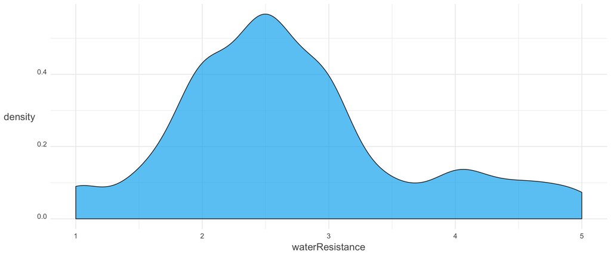

## Water Resistance by Brand

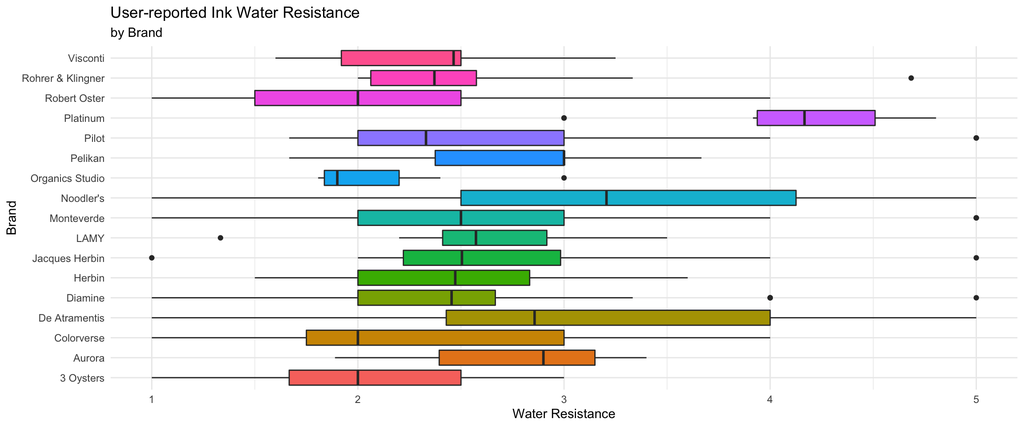

### Top-rated Inks (Low Water Resistance)

These inks were selected for a water resistance score less than or equal to three (low), a review count over 30, and a value rating of over 4.5.

| Brand | Ink | Volume | Reviews | Rating | Drying | Flow | Shading | Value | WaterResistance | Link |
| --- | --- | --- | --- | --- | --- | --- | --- | --- | --- | --- |
| Noodler’s | Bluerase Waterase Ink | 4.5oz | 36 | 4.5 | 3.00 | 4.27 | 2.18 | 4.55 | 1.27 | [Bluerase Waterase Ink](https://www.gouletpens.com/products/noodlers-bluerase-waterase-ink-4-5oz-bottled-ink?variant=11884745130027) |
| Noodler’s | Turquoise Eel | 3oz | 36 | 4.7 | 2.83 | 4.08 | 3.58 | 4.92 | 1.73 | [Turquoise Eel](https://www.gouletpens.com/products/noodlers-turquoise-eel-3oz-bottled-ink?variant=11884743819307) |
| Noodler’s | Blackerase Waterase Ink | 4.5oz | 40 | 4.8 | 3.30 | 3.90 | 2.20 | 4.60 | 2.00 | [Blackerase Waterase Ink](https://www.gouletpens.com/products/noodlers-blackerase-waterase-ink-4-5oz-bottled-ink?variant=11884745064491) |
| Monteverde | Horizon Blue | 90ml | 46 | 4.8 | 3.90 | 3.90 | 2.52 | 4.54 | 2.13 | [Horizon Blue](https://www.gouletpens.com/products/monteverde-horizon-blue-90ml-bottled-ink?variant=11884721176619) |
| Noodler’s | Midnight Blue | 3oz | 30 | 4.6 | 2.50 | 3.67 | 3.17 | 5.00 | 2.17 | [Midnight Blue](https://www.gouletpens.com/products/noodlers-midnight-blue-3oz-bottled-ink?variant=11884736053291) |
| Pilot | Iroshizuku Yama-budo | 50ml | 79 | 4.9 | 3.40 | 4.30 | 3.20 | 4.90 | 2.20 | [Iroshizuku Yama-budo](https://www.gouletpens.com/products/pilot-iroshizuku-yama-budo-50ml-bottled-ink?variant=11884756959275) |
| Diamine | Aurora Borealis | 30ml | 32 | 4.8 | 3.82 | 3.68 | 3.57 | 4.64 | 2.21 | [Aurora Borealis](https://www.gouletpens.com/products/diamine-aurora-borealis-30ml-bottled-ink?variant=15377190649899) |
| Noodler’s | Antietam | 3oz | 103 | 4.7 | 3.17 | 3.78 | 3.50 | 4.82 | 2.22 | [Antietam](https://www.gouletpens.com/products/noodlers-antietam-3oz-bottled-ink?variant=11884736446507) |
| Noodler’s | Cactus Fruit Eel | 3oz | 75 | 4.8 | 3.38 | 4.08 | 3.64 | 4.96 | 2.25 | [Cactus Fruit Eel](https://www.gouletpens.com/products/noodlers-cactus-fruit-eel-3oz-bottled-ink?variant=11884743852075) |
| Diamine | Oxblood | 30ml | 79 | 4.8 | 3.47 | 3.93 | 3.30 | 4.64 | 2.27 | [Oxblood](https://www.gouletpens.com/products/diamine-oxblood-30ml-bottled-ink?variant=11884622610475) |
| Diamine | Wild Strawberry | 30ml | 42 | 4.8 | 3.31 | 3.62 | 2.68 | 4.81 | 2.27 | [Wild Strawberry](https://www.gouletpens.com/products/diamine-wild-strawberry-30ml-bottled-ink?variant=11884622839851) |
| Diamine | Majestic Blue | 80ml | 67 | 4.7 | 3.08 | 3.89 | 3.12 | 4.54 | 2.27 | [Majestic Blue](https://www.gouletpens.com/products/diamine-majestic-blue-80ml-bottled-ink?variant=11884626870315) |
| Pilot | Iroshizuku Shin-kai | 50ml | 61 | 4.8 | 3.29 | 4.29 | 2.29 | 4.86 | 2.29 | [Iroshizuku Shin-kai](https://www.gouletpens.com/products/pilot-iroshizuku-shin-kai-50ml-bottled-ink?variant=11884757778475) |
| Noodler’s | Midway Blue | 3oz | 30 | 4.5 | 3.50 | 3.75 | 3.12 | 4.50 | 2.29 | [Midway Blue](https://www.gouletpens.com/products/noodlers-midway-blue-3oz-bottled-ink?variant=11884738805803) |
| Noodler’s | Habanero | 3oz | 91 | 4.7 | 2.82 | 3.97 | 4.26 | 4.68 | 2.30 | [Habanero](https://www.gouletpens.com/products/noodlers-habanero-3oz-bottled-ink?variant=11884736774187) |
| Noodler’s | Ottoman Azure | 3oz | 70 | 4.6 | 2.80 | 3.85 | 3.53 | 4.79 | 2.31 | [Ottoman Azure](https://www.gouletpens.com/products/noodlers-ottoman-azure-3oz-bottled-ink?variant=11884737429547) |
| Diamine | Chocolate Brown | 30ml | 34 | 4.8 | 2.92 | 3.75 | 3.08 | 4.75 | 2.33 | [Chocolate Brown](https://www.gouletpens.com/products/diamine-chocolate-brown-30ml-bottled-ink?variant=11884621987883) |
| Herbin | Cacao du Brésil | 30ml | 37 | 4.8 | 3.70 | 2.90 | 3.00 | 4.70 | 2.33 | [Cacao du Brésil](https://www.gouletpens.com/products/herbin-cacao-du-bresil-30ml-bottled-ink?variant=11884653838379) |
| Diamine | Apple Glory | 30ml | 31 | 4.7 | 3.58 | 3.83 | 3.08 | 4.92 | 2.33 | [Apple Glory](https://www.gouletpens.com/products/diamine-apple-glory-30ml-bottled-ink?variant=11884623626283) |
| Herbin | Lierre Sauvage | 30ml | 44 | 4.7 | 3.82 | 3.90 | 3.55 | 4.73 | 2.36 | [Lierre Sauvage](https://www.gouletpens.com/products/herbin-lierre-sauvage-30ml-bottled-ink?variant=11884653510699) |
| Pilot | Iroshizuku Kon-peki | 50ml | 145 | 4.8 | 3.50 | 3.92 | 3.42 | 4.60 | 2.38 | [Iroshizuku Kon-peki](https://www.gouletpens.com/products/pilot-iroshizuku-kon-peki-50ml-bottled-ink?variant=11884757155883) |
| Noodler’s | Burgundy | 3oz | 34 | 4.8 | 2.83 | 3.83 | 3.00 | 4.67 | 2.40 | [Burgundy](https://www.gouletpens.com/products/noodlers-burgundy-3oz-bottled-ink?variant=11884736348203) |
| Rohrer & Klingner | Alt-Goldgrun | 50ml | 90 | 4.8 | 3.62 | 3.75 | 4.40 | 4.86 | 2.41 | [Alt-Goldgrun](https://www.gouletpens.com/products/rohrer-klingner-alt-goldgrun-50ml-bottled-ink?variant=11884769181739) |
| Noodler’s | Navajo Turquoise | 3oz | 82 | 4.8 | 3.34 | 3.81 | 3.96 | 4.66 | 2.42 | [Navajo Turquoise](https://www.gouletpens.com/products/noodlers-navajo-turquoise-3oz-bottled-ink?variant=11884736643115) |
| Diamine | Sherwood Green | 30ml | 87 | 4.7 | 3.57 | 3.82 | 3.53 | 4.78 | 2.42 | [Sherwood Green](https://www.gouletpens.com/products/diamine-sherwood-green-30ml-bottled-ink?variant=11884622446635) |
| Noodler’s | Blue Eel | 3oz | 89 | 4.6 | 2.86 | 4.07 | 3.29 | 4.79 | 2.42 | [Blue Eel](https://www.gouletpens.com/products/noodlers-blue-eel-3oz-bottled-ink?variant=11884743655467) |
| Noodler’s | Tiananmen | 3oz | 42 | 4.7 | 3.00 | 3.38 | 3.25 | 5.00 | 2.43 | [Tiananmen](https://www.gouletpens.com/products/noodlers-tiananmen-3oz-bottled-ink?variant=11884737462315) |
| LAMY | Turquoise | 50ml | 44 | 4.8 | 3.50 | 3.45 | 3.50 | 4.75 | 2.44 | [Turquoise](https://www.gouletpens.com/products/lamy-turquoise-50ml-bottled-ink?variant=11884712722475) |
| Robert Oster | Fire & Ice | 50ml | 65 | 4.7 | 3.28 | 3.85 | 4.02 | 4.64 | 2.44 | [Fire & Ice](https://www.gouletpens.com/products/robert-oster-fire-ice-50ml-bottled-ink?variant=11884769574955) |
| Noodler’s | Nightshade | 3oz | 30 | 4.6 | 3.33 | 3.42 | 3.42 | 4.58 | 2.44 | [Nightshade](https://www.gouletpens.com/products/noodlers-nightshade-3oz-bottled-ink?variant=11884737003563) |
| Diamine | Oxblood | 80ml | 171 | 4.8 | 3.40 | 3.77 | 3.41 | 4.79 | 2.50 | [Oxblood](https://www.gouletpens.com/products/diamine-oxblood-80ml-bottled-ink?variant=11884629458987) |
| Diamine | Syrah | 80ml | 86 | 4.7 | 4.07 | 3.47 | 3.29 | 4.87 | 2.50 | [Syrah](https://www.gouletpens.com/products/diamine-syrah-80ml-bottled-ink?variant=11884629262379) |
| Noodler’s | Dragon’s Napalm | 4.5oz | 75 | 4.5 | 3.40 | 4.00 | 2.70 | 4.80 | 2.50 | [Dragon’s Napalm](https://www.gouletpens.com/products/noodlers-dragons-napalm-4-5oz-bottled-ink?variant=11884744835115) |
| Pilot | Iroshizuku Fuyu-gaki | 50ml | 45 | 4.5 | 3.50 | 4.00 | 2.00 | 4.50 | 2.50 | [Iroshizuku Fuyu-gaki](https://www.gouletpens.com/products/pilot-iroshizuku-fuyu-gaki-50ml-bottled-ink?variant=11884755484715) |
| Diamine | Ancient Copper | 30ml | 163 | 4.6 | 3.42 | 3.55 | 3.65 | 4.71 | 2.51 | [Ancient Copper](https://www.gouletpens.com/products/diamine-ancient-copper-30ml-bottled-ink?variant=11884622905387) |
| LAMY | Black | 50ml | 33 | 4.6 | 4.23 | 3.38 | 2.92 | 4.69 | 2.55 | [Black](https://www.gouletpens.com/products/lamy-black-50ml-bottled-ink?variant=11884712525867) |
| Noodler’s | Apache Sunset | 3oz | 330 | 4.6 | 3.00 | 3.71 | 4.42 | 4.64 | 2.57 | [Apache Sunset](https://www.gouletpens.com/products/noodlers-apache-sunset-3oz-bottled-ink?variant=11884736839723) |
| Noodler’s | Army Green | 3oz | 47 | 4.6 | 3.14 | 3.43 | 3.57 | 5.00 | 2.57 | [Army Green](https://www.gouletpens.com/products/noodlers-army-green-3oz-bottled-ink?variant=11884735725611) |
| Diamine | Twilight | 30ml | 53 | 4.7 | 3.92 | 3.60 | 3.32 | 4.73 | 2.58 | [Twilight](https://www.gouletpens.com/products/diamine-twilight-30ml-bottled-ink?variant=11884622381099) |
| Diamine | Eclipse | 30ml | 42 | 4.7 | 3.86 | 3.57 | 2.95 | 4.82 | 2.60 | [Eclipse](https://www.gouletpens.com/products/diamine-eclipse-30ml-bottled-ink?variant=11884622708779) |
| Noodler’s | Gruene Cactus | 3oz | 33 | 4.7 | 3.50 | 3.33 | 3.83 | 5.00 | 2.60 | [Gruene Cactus](https://www.gouletpens.com/products/noodlers-gruene-cactus-3oz-bottled-ink?variant=11884737331243) |
| Diamine | Red Dragon | 80ml | 120 | 4.8 | 3.66 | 3.97 | 2.68 | 4.73 | 2.63 | [Red Dragon](https://www.gouletpens.com/products/diamine-red-dragon-80ml-bottled-ink?variant=11884628049963) |
| Noodler’s | Nikita | 4.5oz | 98 | 4.7 | 3.33 | 4.08 | 2.58 | 4.83 | 2.64 | [Nikita](https://www.gouletpens.com/products/noodlers-nikita-4-5oz-bottled-ink?variant=11884744146987) |
| Noodler’s | Gruene Cactus Eel | 3oz | 57 | 4.6 | 3.31 | 3.46 | 3.38 | 4.85 | 2.64 | [Gruene Cactus Eel](https://www.gouletpens.com/products/noodlers-gruene-cactus-eel-3oz-bottled-ink?variant=11884742311979) |
| Diamine | Red Dragon | 30ml | 46 | 4.8 | 3.77 | 3.55 | 2.85 | 4.61 | 2.65 | [Red Dragon](https://www.gouletpens.com/products/diamine-red-dragon-30ml-bottled-ink?variant=11884622544939) |
| Pilot | Iroshizuku Asa-gao | 50ml | 75 | 4.8 | 3.79 | 4.00 | 2.71 | 4.50 | 2.71 | [Iroshizuku Asa-gao](https://www.gouletpens.com/products/pilot-iroshizuku-asa-gao-50ml-bottled-ink?variant=11884755714091) |
| Diamine | Bilberry | 30ml | 40 | 4.7 | 3.53 | 3.94 | 2.71 | 4.65 | 2.71 | [Bilberry](https://www.gouletpens.com/products/diamine-bilberry-30ml-bottled-ink?variant=11884622938155) |
| Noodler’s | Golden Brown | 3oz | 60 | 4.7 | 3.00 | 4.00 | 4.20 | 4.63 | 2.72 | [Golden Brown](https://www.gouletpens.com/products/noodlers-golden-brown-3oz-bottled-ink?variant=11884736315435) |
| Noodler’s | Dragon’s Napalm | 3oz | 84 | 4.5 | 3.28 | 3.94 | 2.94 | 4.94 | 2.72 | [Dragon’s Napalm](https://www.gouletpens.com/products/noodlers-dragons-napalm-3oz-bottled-ink?variant=11884738019371) |
| Noodler’s | Cayenne | 3oz | 42 | 4.6 | 3.33 | 3.67 | 3.67 | 4.50 | 2.73 | [Cayenne](https://www.gouletpens.com/products/noodlers-cayenne-3oz-bottled-ink?variant=11884736708651) |
| De Atramentis | Alexander Hamilton | 35ml | 35 | 4.9 | 3.41 | 4.22 | 3.26 | 4.84 | 2.75 | [Alexander Hamilton](https://www.gouletpens.com/products/de-atramentis-alexander-hamilton-35ml-bottled-ink?variant=11884638896171) |
| Diamine | Asa Blue | 30ml | 34 | 4.7 | 3.62 | 3.85 | 3.64 | 4.77 | 2.75 | [Asa Blue](https://www.gouletpens.com/products/diamine-asa-blue-30ml-bottled-ink?variant=11884622643243) |
| Diamine | Midnight | 30ml | 35 | 4.8 | 3.27 | 3.82 | 3.18 | 4.73 | 2.78 | [Midnight](https://www.gouletpens.com/products/diamine-midnight-30ml-bottled-ink?variant=11884622151723) |
| Diamine | Sargasso Sea | 30ml | 43 | 4.4 | 2.93 | 3.64 | 2.85 | 4.54 | 2.78 | [Sargasso Sea](https://www.gouletpens.com/products/diamine-sargasso-sea-30ml-bottled-ink?variant=11884624248875) |
| Herbin | Lie de The | 30ml | 48 | 4.8 | 3.92 | 3.77 | 4.00 | 4.54 | 2.83 | [Lie de The](https://www.gouletpens.com/products/herbin-lie-de-the-30ml-bottled-ink?variant=11884653707307) |
| Herbin | Perle Noire | 30ml | 60 | 4.6 | 3.71 | 4.00 | 1.87 | 4.65 | 2.83 | [Perle Noire](https://www.gouletpens.com/products/herbin-perle-noire-30ml-bottled-ink?variant=11884652134443) |
| Diamine | Imperial Purple | 30ml | 32 | 4.7 | 3.86 | 3.33 | 3.10 | 4.61 | 2.84 | [Imperial Purple](https://www.gouletpens.com/products/diamine-imperial-purple-30ml-bottled-ink?variant=11884621168683) |
| Noodler’s | Green Marine | 3oz | 43 | 4.7 | 3.33 | 4.00 | 3.40 | 4.73 | 2.86 | [Green Marine](https://www.gouletpens.com/products/noodlers-green-marine-3oz-bottled-ink?variant=11884737658923) |
| Noodler’s | Blue | 3oz | 76 | 4.7 | 3.48 | 3.59 | 3.04 | 4.63 | 2.87 | [Blue](https://www.gouletpens.com/products/noodlers-blue-3oz-bottled-ink?variant=11884735922219) |
| Noodler’s | Kiowa Pecan | 3oz | 57 | 4.7 | 3.27 | 3.69 | 4.00 | 4.69 | 2.94 | [Kiowa Pecan](https://www.gouletpens.com/products/noodlers-kiowa-pecan-3oz-bottled-ink?variant=11884736249899) |
| Pilot | Iroshizuku Yama-guri | 50ml | 45 | 4.8 | 3.50 | 4.25 | 2.75 | 4.75 | 3.00 | [Iroshizuku Yama-guri](https://www.gouletpens.com/products/pilot-iroshizuku-yama-guri-50ml-bottled-ink?variant=11884757516331) |
| Noodler’s | Squeteague | 3oz | 43 | 4.7 | 3.50 | 3.67 | 3.58 | 4.92 | 3.00 | [Squeteague](https://www.gouletpens.com/products/noodlers-squeteague-3oz-bottled-ink?variant=11884736872491) |
| Pelikan | Brilliant Black 4001 | 2oz | 31 | 4.7 | 3.67 | 3.67 | 3.60 | 4.67 | 3.00 | [Brilliant Black 4001](https://www.gouletpens.com/products/pelikan-brilliant-black-4001-2oz-bottled-ink?variant=11884750143531) |
| Pilot | Iroshizuku Yu-yake | 50ml | 42 | 4.7 | 4.60 | 4.20 | 3.60 | 5.00 | 3.00 | [Iroshizuku Yu-yake](https://www.gouletpens.com/products/pilot-iroshizuku-yu-yake-50ml-bottled-ink?variant=11884757090347) |
| Noodler’s | Borealis Black | 4.5oz | 51 | 4.6 | 3.40 | 3.80 | 3.25 | 4.50 | 3.00 | [Borealis Black](https://www.gouletpens.com/products/noodlers-borealis-black-4-5oz-bottled-ink?variant=11884744900651) |
| Pilot | Namiki Black | 60ml | 30 | 4.4 | 4.00 | 4.00 | 3.00 | 5.00 | 3.00 | [Namiki Black](https://www.gouletpens.com/products/pilot-namiki-black-60ml-bottled-ink?variant=11884755615787) |

### Top-rated Inks (High Water Resistance)

These inks were selected for a water resistance score greater than or equal to four (high), a review count over 30, and a value rating of over 4.5.

| Brand | Ink | Volume | Reviews | Rating | Drying | Flow | Shading | Value | WaterResistance | Link |
| --- | --- | --- | --- | --- | --- | --- | --- | --- | --- | --- |
| Pilot | Iroshizuku Syo-ro | 50ml | 39 | 4.6 | 5.00 | 5.00 | 4.00 | 5.00 | 5.00 | [Iroshizuku Syo-ro](https://www.gouletpens.com/products/pilot-iroshizuku-syo-ro-50ml-bottled-ink?variant=11884756828203) |
| Platinum | Carbon Black | 60ml | 99 | 4.8 | 3.61 | 3.46 | 2.45 | 4.57 | 4.80 | [Carbon Black](https://www.gouletpens.com/products/platinum-carbon-black-60ml-bottled-ink?variant=11884753027115) |
| De Atramentis | Document Ink Black | 35ml | 69 | 4.9 | 4.05 | 3.93 | 3.19 | 4.57 | 4.76 | [Document Ink Black](https://www.gouletpens.com/products/de-atramentis-document-black-35ml-bottled-ink?variant=11884635324459) |
| Rohrer & Klingner | Salix | 50ml | 53 | 4.7 | 3.90 | 2.95 | 3.45 | 4.89 | 4.68 | [Salix](https://www.gouletpens.com/products/rohrer-klingner-salix-50ml-bottled-ink?variant=11884769902635) |
| Noodler’s | Polar Blue | 3oz | 40 | 4.4 | 4.00 | 3.92 | 1.77 | 4.69 | 4.67 | [Polar Blue](https://www.gouletpens.com/products/noodlers-polar-blue-3oz-bottled-ink?variant=11884743950379) |
| De Atramentis | Archive Ink | 35ml | 37 | 4.9 | 4.11 | 4.00 | 2.77 | 4.71 | 4.63 | [Archive Ink](https://www.gouletpens.com/products/de-atramentis-archive-35ml-bottled-ink?variant=11884635389995) |
| Noodler’s | Bad Green Gator | 3oz | 75 | 4.2 | 4.00 | 3.88 | 3.25 | 5.00 | 4.62 | [Bad Green Gator](https://www.gouletpens.com/products/noodlers-bad-green-gator-3oz-bottled-ink?variant=11884740018219) |
| Noodler’s | Lexington Gray | 4.5oz | 119 | 4.8 | 4.31 | 4.08 | 4.08 | 4.62 | 4.60 | [Lexington Gray](https://www.gouletpens.com/products/noodlers-lexington-gray-4-5oz-bottled-ink?variant=11884744343595) |
| Noodler’s | Lexington Gray | 3oz | 173 | 4.7 | 3.84 | 3.76 | 3.39 | 4.74 | 4.56 | [Lexington Gray](https://www.gouletpens.com/products/noodlers-lexington-gray-3oz-bottled-ink?variant=11884737822763) |
| Noodler’s | Year of the Golden Pig | 4.5oz | 36 | 4.0 | 4.20 | 3.80 | 1.40 | 5.00 | 4.50 | [Year of the Golden Pig](https://www.gouletpens.com/products/noodlers-year-golden-pig-4-5oz-bottled-ink?variant=11884744376363) |
| Noodler’s | Bad Black Moccasin | 3oz | 78 | 4.7 | 4.05 | 3.72 | 2.28 | 4.79 | 4.47 | [Bad Black Moccasin](https://www.gouletpens.com/products/noodlers-bad-black-moccasin-3oz-bottled-ink?variant=11884739887147) |
| Noodler’s | Black | 3oz | 361 | 4.7 | 3.44 | 3.60 | 2.58 | 4.70 | 4.23 | [Black](https://www.gouletpens.com/products/noodlers-black-3oz-bottled-ink?variant=11884735791147) |
| Noodler’s | Rome Burning | 3oz | 54 | 4.1 | 4.00 | 3.85 | 2.33 | 4.50 | 4.23 | [Rome Burning](https://www.gouletpens.com/products/noodlers-rome-burning-3oz-bottled-ink?variant=11884739854379) |
| Noodler’s | Black Eel | 3oz | 132 | 4.7 | 3.33 | 3.90 | 2.74 | 4.71 | 4.21 | [Black Eel](https://www.gouletpens.com/products/noodlers-black-eel-3oz-bottled-ink?variant=11884743917611) |
| Noodler’s | El Lawrence | 3oz | 65 | 4.7 | 3.39 | 3.76 | 2.33 | 4.67 | 4.20 | [El Lawrence](https://www.gouletpens.com/products/noodlers-el-lawrence-3oz-bottled-ink?variant=11884743524395) |
| Noodler’s | X-Feather | 4.5oz | 133 | 4.7 | 3.56 | 3.46 | 1.70 | 4.68 | 4.13 | [X-Feather](https://www.gouletpens.com/products/noodlers-x-feather-4-5oz-bottled-ink?variant=11884744966187) |
| Noodler’s | Baystate Blue | 4.5oz | 283 | 4.7 | 3.77 | 3.77 | 2.45 | 4.77 | 4.11 | [Baystate Blue](https://www.gouletpens.com/products/noodlers-baystate-blue-4-5oz-bottled-ink?variant=11884744769579) |
| Noodler’s | Bad Belted Kingfisher | 3oz | 141 | 4.6 | 3.61 | 4.22 | 2.12 | 4.67 | 4.11 | [Bad Belted Kingfisher](https://www.gouletpens.com/products/noodlers-bad-belted-kingfisher-3oz-bottled-ink?variant=11884739919915) |
| Noodler’s | Heart of Darkness | 4.5oz | 315 | 4.7 | 3.96 | 3.90 | 2.04 | 4.72 | 4.10 | [Heart of Darkness](https://www.gouletpens.com/products/noodlers-heart-darkness-4-5oz-bottled-ink?variant=11884744572971) |
| Noodler’s | Baystate Blue | 3oz | 317 | 4.5 | 3.57 | 3.77 | 2.31 | 4.63 | 4.09 | [Baystate Blue](https://www.gouletpens.com/products/noodlers-baystate-blue-3oz-bottled-ink?variant=11884737626155) |
| Noodler’s | Blue Ghost | 3oz | 79 | 4.8 | 3.31 | 3.50 | 1.56 | 4.81 | 4.08 | [Blue Ghost](https://www.gouletpens.com/products/noodlers-blue-ghost-3oz-bottled-ink?variant=11884742770731) |
| Noodler’s | General of the Armies | 3oz | 30 | 4.6 | 3.79 | 3.47 | 3.21 | 4.77 | 4.00 | [General of the Armies](https://www.gouletpens.com/products/noodlers-general-armies-3oz-bottled-ink?variant=11884740444203) |
| Noodler’s | Polar Black | 3oz | 35 | 4.6 | 2.86 | 4.00 | 1.83 | 4.86 | 4.00 | [Polar Black](https://www.gouletpens.com/products/noodlers-polar-black-3oz-bottled-ink?variant=11884742934571) |

# Top-ranked Inks

The following list of inks was created by filtering for inks with 50 or more reviews and a value of 4.5 or greater for both rating and value. The results were then sorted by rating and review count, respectively.

| Brand | Ink | Volume | Reviews | Rating | Drying | Flow | Shading | Value | WaterResistance | Link |
| --- | --- | --- | --- | --- | --- | --- | --- | --- | --- | --- |
| Pilot | Iroshizuku Yama-budo | 50ml | 79 | 4.9 | 3.40 | 4.30 | 3.20 | 4.90 | 2.20 | [Iroshizuku Yama-budo](https://www.gouletpens.com/products/pilot-iroshizuku-yama-budo-50ml-bottled-ink?variant=11884756959275) |
| De Atramentis | Document Ink Black | 35ml | 69 | 4.9 | 4.05 | 3.93 | 3.19 | 4.57 | 4.76 | [Document Ink Black](https://www.gouletpens.com/products/de-atramentis-document-black-35ml-bottled-ink?variant=11884635324459) |
| Pilot | Iroshizuku Take-sumi | 50ml | 67 | 4.9 | 4.00 | 4.29 | 3.18 | 4.71 | 3.06 | [Iroshizuku Take-sumi](https://www.gouletpens.com/products/pilot-iroshizuku-take-sumi-50ml-bottled-ink?variant=11884757745707) |
| Noodler’s | Black Swan in Australian Roses | 3oz | 278 | 4.8 | 3.18 | 3.69 | 4.00 | 4.80 | 3.25 | [Black Swan in Australian Roses](https://www.gouletpens.com/products/noodlers-black-swan-australian-roses-3oz-bottled-ink?variant=11884740116523) |
| Diamine | Oxblood | 80ml | 171 | 4.8 | 3.40 | 3.77 | 3.41 | 4.79 | 2.50 | [Oxblood](https://www.gouletpens.com/products/diamine-oxblood-80ml-bottled-ink?variant=11884629458987) |
| Pilot | Iroshizuku Kon-peki | 50ml | 145 | 4.8 | 3.50 | 3.92 | 3.42 | 4.60 | 2.38 | [Iroshizuku Kon-peki](https://www.gouletpens.com/products/pilot-iroshizuku-kon-peki-50ml-bottled-ink?variant=11884757155883) |
| Noodler’s | Blue Ghost | 4.5oz | 121 | 4.8 | 3.78 | 3.52 | 1.92 | 4.81 | 3.45 | [Blue Ghost](https://www.gouletpens.com/products/noodlers-blue-ghost-4-5oz-bottled-ink?variant=11884744540203) |
| Diamine | Red Dragon | 80ml | 120 | 4.8 | 3.66 | 3.97 | 2.68 | 4.73 | 2.63 | [Red Dragon](https://www.gouletpens.com/products/diamine-red-dragon-80ml-bottled-ink?variant=11884628049963) |
| Noodler’s | Lexington Gray | 4.5oz | 119 | 4.8 | 4.31 | 4.08 | 4.08 | 4.62 | 4.60 | [Lexington Gray](https://www.gouletpens.com/products/noodlers-lexington-gray-4-5oz-bottled-ink?variant=11884744343595) |
| Platinum | Carbon Black | 60ml | 99 | 4.8 | 3.61 | 3.46 | 2.45 | 4.57 | 4.80 | [Carbon Black](https://www.gouletpens.com/products/platinum-carbon-black-60ml-bottled-ink?variant=11884753027115) |
| Rohrer & Klingner | Alt-Goldgrun | 50ml | 90 | 4.8 | 3.62 | 3.75 | 4.40 | 4.86 | 2.41 | [Alt-Goldgrun](https://www.gouletpens.com/products/rohrer-klingner-alt-goldgrun-50ml-bottled-ink?variant=11884769181739) |
| Noodler’s | Navajo Turquoise | 3oz | 82 | 4.8 | 3.34 | 3.81 | 3.96 | 4.66 | 2.42 | [Navajo Turquoise](https://www.gouletpens.com/products/noodlers-navajo-turquoise-3oz-bottled-ink?variant=11884736643115) |
| Diamine | Oxblood | 30ml | 79 | 4.8 | 3.47 | 3.93 | 3.30 | 4.64 | 2.27 | [Oxblood](https://www.gouletpens.com/products/diamine-oxblood-30ml-bottled-ink?variant=11884622610475) |
| Noodler’s | Blue Ghost | 3oz | 79 | 4.8 | 3.31 | 3.50 | 1.56 | 4.81 | 4.08 | [Blue Ghost](https://www.gouletpens.com/products/noodlers-blue-ghost-3oz-bottled-ink?variant=11884742770731) |
| Noodler’s | Cactus Fruit Eel | 3oz | 75 | 4.8 | 3.38 | 4.08 | 3.64 | 4.96 | 2.25 | [Cactus Fruit Eel](https://www.gouletpens.com/products/noodlers-cactus-fruit-eel-3oz-bottled-ink?variant=11884743852075) |
| Pilot | Iroshizuku Asa-gao | 50ml | 75 | 4.8 | 3.79 | 4.00 | 2.71 | 4.50 | 2.71 | [Iroshizuku Asa-gao](https://www.gouletpens.com/products/pilot-iroshizuku-asa-gao-50ml-bottled-ink?variant=11884755714091) |
| Pilot | Iroshizuku Shin-kai | 50ml | 61 | 4.8 | 3.29 | 4.29 | 2.29 | 4.86 | 2.29 | [Iroshizuku Shin-kai](https://www.gouletpens.com/products/pilot-iroshizuku-shin-kai-50ml-bottled-ink?variant=11884757778475) |
| Noodler’s | Black | 3oz | 361 | 4.7 | 3.44 | 3.60 | 2.58 | 4.70 | 4.23 | [Black](https://www.gouletpens.com/products/noodlers-black-3oz-bottled-ink?variant=11884735791147) |
| Noodler’s | Heart of Darkness | 4.5oz | 315 | 4.7 | 3.96 | 3.90 | 2.04 | 4.72 | 4.10 | [Heart of Darkness](https://www.gouletpens.com/products/noodlers-heart-darkness-4-5oz-bottled-ink?variant=11884744572971) |
| Noodler’s | Baystate Blue | 4.5oz | 283 | 4.7 | 3.77 | 3.77 | 2.45 | 4.77 | 4.11 | [Baystate Blue](https://www.gouletpens.com/products/noodlers-baystate-blue-4-5oz-bottled-ink?variant=11884744769579) |
| Noodler’s | Lexington Gray | 3oz | 173 | 4.7 | 3.84 | 3.76 | 3.39 | 4.74 | 4.56 | [Lexington Gray](https://www.gouletpens.com/products/noodlers-lexington-gray-3oz-bottled-ink?variant=11884737822763) |
| Noodler’s | Air-Corp Blue-Black | 3oz | 154 | 4.7 | 3.29 | 3.73 | 3.04 | 4.76 | 3.53 | [Air-Corp Blue-Black](https://www.gouletpens.com/products/noodlers-air-corp-blue-black-3oz-bottled-ink?variant=11884737724459) |
| Noodler’s | X-Feather | 4.5oz | 133 | 4.7 | 3.56 | 3.46 | 1.70 | 4.68 | 4.13 | [X-Feather](https://www.gouletpens.com/products/noodlers-x-feather-4-5oz-bottled-ink?variant=11884744966187) |
| Noodler’s | Black Eel | 3oz | 132 | 4.7 | 3.33 | 3.90 | 2.74 | 4.71 | 4.21 | [Black Eel](https://www.gouletpens.com/products/noodlers-black-eel-3oz-bottled-ink?variant=11884743917611) |
| Noodler’s | Antietam | 3oz | 103 | 4.7 | 3.17 | 3.78 | 3.50 | 4.82 | 2.22 | [Antietam](https://www.gouletpens.com/products/noodlers-antietam-3oz-bottled-ink?variant=11884736446507) |
| Noodler’s | Nikita | 4.5oz | 98 | 4.7 | 3.33 | 4.08 | 2.58 | 4.83 | 2.64 | [Nikita](https://www.gouletpens.com/products/noodlers-nikita-4-5oz-bottled-ink?variant=11884744146987) |
| Noodler’s | Habanero | 3oz | 91 | 4.7 | 2.82 | 3.97 | 4.26 | 4.68 | 2.30 | [Habanero](https://www.gouletpens.com/products/noodlers-habanero-3oz-bottled-ink?variant=11884736774187) |
| Diamine | Sherwood Green | 30ml | 87 | 4.7 | 3.57 | 3.82 | 3.53 | 4.78 | 2.42 | [Sherwood Green](https://www.gouletpens.com/products/diamine-sherwood-green-30ml-bottled-ink?variant=11884622446635) |
| Diamine | Syrah | 80ml | 86 | 4.7 | 4.07 | 3.47 | 3.29 | 4.87 | 2.50 | [Syrah](https://www.gouletpens.com/products/diamine-syrah-80ml-bottled-ink?variant=11884629262379) |
| Noodler’s | Bad Black Moccasin | 3oz | 78 | 4.7 | 4.05 | 3.72 | 2.28 | 4.79 | 4.47 | [Bad Black Moccasin](https://www.gouletpens.com/products/noodlers-bad-black-moccasin-3oz-bottled-ink?variant=11884739887147) |
| Noodler’s | Blue | 3oz | 76 | 4.7 | 3.48 | 3.59 | 3.04 | 4.63 | 2.87 | [Blue](https://www.gouletpens.com/products/noodlers-blue-3oz-bottled-ink?variant=11884735922219) |
| Noodler’s | Blue-Black | 3oz | 73 | 4.7 | 3.35 | 3.76 | 2.47 | 4.76 | 3.44 | [Blue-Black](https://www.gouletpens.com/products/noodlers-blue-black-3oz-bottled-ink?variant=11884736413739) |
| Noodler’s | Purple Heart | 3oz | 72 | 4.7 | 3.65 | 3.89 | 3.79 | 4.60 | 3.17 | [Purple Heart](https://www.gouletpens.com/products/noodlers-purple-heart-3oz-bottled-ink?variant=11884745228331) |
| Noodler’s | Navy | 3oz | 68 | 4.7 | 3.29 | 3.86 | 3.57 | 4.82 | 3.12 | [Navy](https://www.gouletpens.com/products/noodlers-navy-3oz-bottled-ink?variant=11884737101867) |
| Diamine | Majestic Blue | 80ml | 67 | 4.7 | 3.08 | 3.89 | 3.12 | 4.54 | 2.27 | [Majestic Blue](https://www.gouletpens.com/products/diamine-majestic-blue-80ml-bottled-ink?variant=11884626870315) |
| Noodler’s | El Lawrence | 3oz | 65 | 4.7 | 3.39 | 3.76 | 2.33 | 4.67 | 4.20 | [El Lawrence](https://www.gouletpens.com/products/noodlers-el-lawrence-3oz-bottled-ink?variant=11884743524395) |
| Robert Oster | Fire & Ice | 50ml | 65 | 4.7 | 3.28 | 3.85 | 4.02 | 4.64 | 2.44 | [Fire & Ice](https://www.gouletpens.com/products/robert-oster-fire-ice-50ml-bottled-ink?variant=11884769574955) |
| Noodler’s | Golden Brown | 3oz | 60 | 4.7 | 3.00 | 4.00 | 4.20 | 4.63 | 2.72 | [Golden Brown](https://www.gouletpens.com/products/noodlers-golden-brown-3oz-bottled-ink?variant=11884736315435) |
| Noodler’s | Kiowa Pecan | 3oz | 57 | 4.7 | 3.27 | 3.69 | 4.00 | 4.69 | 2.94 | [Kiowa Pecan](https://www.gouletpens.com/products/noodlers-kiowa-pecan-3oz-bottled-ink?variant=11884736249899) |
| Diamine | Twilight | 30ml | 53 | 4.7 | 3.92 | 3.60 | 3.32 | 4.73 | 2.58 | [Twilight](https://www.gouletpens.com/products/diamine-twilight-30ml-bottled-ink?variant=11884622381099) |
| Rohrer & Klingner | Salix | 50ml | 53 | 4.7 | 3.90 | 2.95 | 3.45 | 4.89 | 4.68 | [Salix](https://www.gouletpens.com/products/rohrer-klingner-salix-50ml-bottled-ink?variant=11884769902635) |
| Noodler’s | Liberty’s Elysium | 3oz | 449 | 4.6 | 3.71 | 3.54 | 2.93 | 4.53 | 3.57 | [Liberty’s Elysium](https://www.gouletpens.com/products/noodlers-libertys-elysium-3oz-bottled-ink?variant=11884745261099) |
| Noodler’s | Apache Sunset | 3oz | 330 | 4.6 | 3.00 | 3.71 | 4.42 | 4.64 | 2.57 | [Apache Sunset](https://www.gouletpens.com/products/noodlers-apache-sunset-3oz-bottled-ink?variant=11884736839723) |
| Diamine | Ancient Copper | 30ml | 163 | 4.6 | 3.42 | 3.55 | 3.65 | 4.71 | 2.51 | [Ancient Copper](https://www.gouletpens.com/products/diamine-ancient-copper-30ml-bottled-ink?variant=11884622905387) |
| Noodler’s | X-Feather | 3oz | 160 | 4.6 | 3.05 | 3.38 | 1.83 | 4.65 | 3.80 | [X-Feather](https://www.gouletpens.com/products/noodlers-x-feather-3oz-bottled-ink?variant=11884737986603) |
| Noodler’s | Bad Belted Kingfisher | 3oz | 141 | 4.6 | 3.61 | 4.22 | 2.12 | 4.67 | 4.11 | [Bad Belted Kingfisher](https://www.gouletpens.com/products/noodlers-bad-belted-kingfisher-3oz-bottled-ink?variant=11884739919915) |
| Noodler’s | Black Swan in English Roses | 3oz | 105 | 4.6 | 3.27 | 3.50 | 3.00 | 4.64 | 3.08 | [Black Swan in English Roses](https://www.gouletpens.com/products/noodlers-black-swan-english-roses-3oz-bottled-ink?variant=11884737560619) |
| Noodler’s | Blue Eel | 3oz | 89 | 4.6 | 2.86 | 4.07 | 3.29 | 4.79 | 2.42 | [Blue Eel](https://www.gouletpens.com/products/noodlers-blue-eel-3oz-bottled-ink?variant=11884743655467) |
| Noodler’s | Ottoman Azure | 3oz | 70 | 4.6 | 2.80 | 3.85 | 3.53 | 4.79 | 2.31 | [Ottoman Azure](https://www.gouletpens.com/products/noodlers-ottoman-azure-3oz-bottled-ink?variant=11884737429547) |
| Herbin | Perle Noire | 30ml | 60 | 4.6 | 3.71 | 4.00 | 1.87 | 4.65 | 2.83 | [Perle Noire](https://www.gouletpens.com/products/herbin-perle-noire-30ml-bottled-ink?variant=11884652134443) |
| Noodler’s | Dark Matter | 3oz | 59 | 4.6 | 3.67 | 3.56 | 2.53 | 4.50 | 3.13 | [Dark Matter](https://www.gouletpens.com/products/noodlers-dark-matter-3oz-bottled-ink?variant=11884738445355) |
| Noodler’s | Gruene Cactus Eel | 3oz | 57 | 4.6 | 3.31 | 3.46 | 3.38 | 4.85 | 2.64 | [Gruene Cactus Eel](https://www.gouletpens.com/products/noodlers-gruene-cactus-eel-3oz-bottled-ink?variant=11884742311979) |
| Noodler’s | Borealis Black | 4.5oz | 51 | 4.6 | 3.40 | 3.80 | 3.25 | 4.50 | 3.00 | [Borealis Black](https://www.gouletpens.com/products/noodlers-borealis-black-4-5oz-bottled-ink?variant=11884744900651) |
| Noodler’s | Baystate Blue | 3oz | 317 | 4.5 | 3.57 | 3.77 | 2.31 | 4.63 | 4.09 | [Baystate Blue](https://www.gouletpens.com/products/noodlers-baystate-blue-3oz-bottled-ink?variant=11884737626155) |
| Noodler’s | Red Black | 3oz | 107 | 4.5 | 3.32 | 3.87 | 4.00 | 4.84 | 3.54 | [Red Black](https://www.gouletpens.com/products/noodlers-red-black-3oz-bottled-ink?variant=11884736184363) |
| Noodler’s | Dragon’s Napalm | 3oz | 84 | 4.5 | 3.28 | 3.94 | 2.94 | 4.94 | 2.72 | [Dragon’s Napalm](https://www.gouletpens.com/products/noodlers-dragons-napalm-3oz-bottled-ink?variant=11884738019371) |
| Noodler’s | Dragon’s Napalm | 4.5oz | 75 | 4.5 | 3.40 | 4.00 | 2.70 | 4.80 | 2.50 | [Dragon’s Napalm](https://www.gouletpens.com/products/noodlers-dragons-napalm-4-5oz-bottled-ink?variant=11884744835115) |